# Ecosystems Assessment: Maine - New Brunswick Foothills and Lowlands Ecological Section

Author

Randy Swaty

Published

May 26, 2026

## Location and Background

Principle 6 of the FSC US FSS aims to maximize positive environmental impacts and minimize adverse environmental impacts of management activities occurring within certified management units. Toward this desired outcome, Criterion 6.5 requires the identification and protection or restoration of native ecosystems that are not already adequately represented and protected in the landscape, defined here as the Ecological Section named above, and in the locator map to the right.

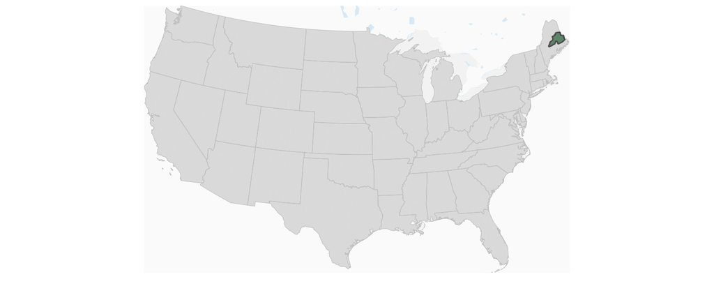

This tool serves to support certificate holders with the requirements of Criterion 6.5 related to Representative Sample Areas, but importantly, does not ensure conformance. Additional information gathering and evaluation will most likely be required by certificate holders to ensure conformance with the elements of Criterion 6.5. It is not possible to establish a blanket measurement by which to determine “adequate” protection of all various and complex native ecosystems across the entirety of the conterminous US.

This tool primarily helps with elements of Indicator 6.5.1, and may additionally assist in conformance with Indicators 6.5.2 - 6.5.6.

## Native and Existing Vegetation Types

This first section helps to identify the native ecosystems that should occur in the landscape given the existing climate and soil conditions (an essential element of Indicator 6.5.1), as well as ecosystems that are currently present within the landscape. Importantly, these assessments only cover the top 10 most prevalent ecosystems. Additionally, this section also provides tables of the top 3 ecosystem types that should occur given historic data broken down to identify percentage remaining or converted to currently present ecosystems.

We quantified Native Ecosystems using LANDFIRE’s (Biophysical Settings)[https://landfire.gov/vegetation/bps] data and Existing Ecosystems using LANDFIRE’s (Existing Vegetation Type-Ecological Systems)[https://landfire.gov/vegetation/evt] data. See more about these datasets in “Key Concepts” section below.

### Native Ecosystems

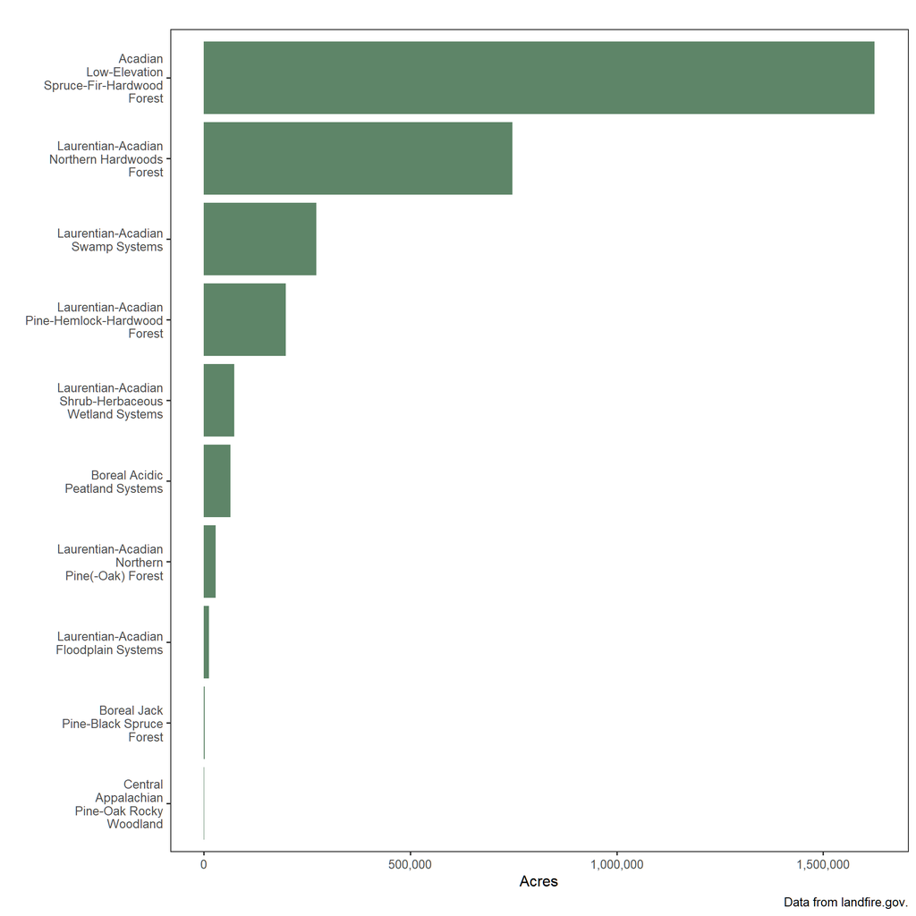

### Existing Ecosystems - 2024

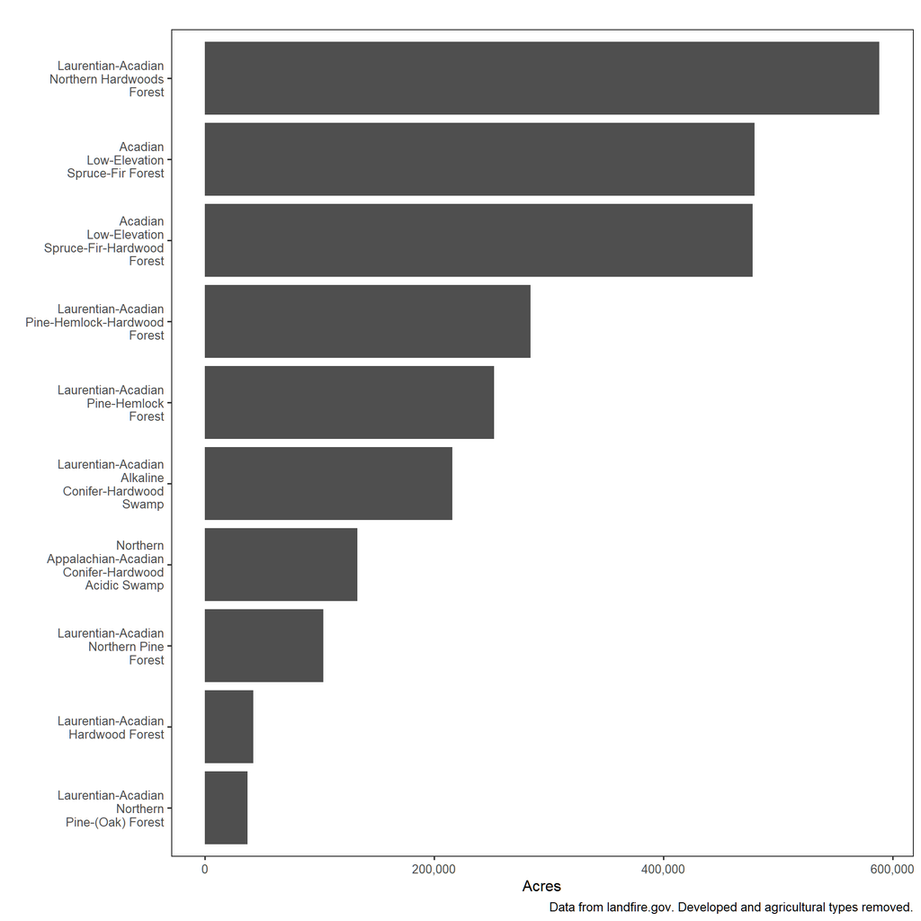

### Flow chart: Composition of Existing Ecosystems within the three most prevalent Native Ecosystem footprints

For the charts below we assessed the amounts of each Existing Ecosystem (at a coarse level; includes agricultural and developed types) within each of the top 3 most prevalent Native Ecosystem footprints for this Ecological Section.

**Hover over the grey horizontal bands to explore how Native Ecosystems have split out on the current landscape. Current percent of each Existing Ecosystem for this Ecological Section quantified in parentheses.**

Acadian Low-Elevation Spruce-Fir-Hardwood Forest (61%)

[interactive chart not shown]

Laurentian-Acadian Northern Hardwoods Forest (28%)

[interactive chart not shown]

Laurentian-Acadian Swamp Systems (10%)

[interactive chart not shown]

## GAP Status

**The GAP status codes are defined as (copied from https://www.usgs.gov/programs/gap-analysis-project/gap-status-code-frequently-asked-questions-faq):**

**Gap Status 1:** An area having permanent protection from conversion of natural land cover and a mandated management plan in operation to maintain a natural state within which disturbance events (of natural type, frequency, intensity, and legacy) are allowed to proceed without interference or are mimicked through management.

**Gap Status 2:** An area having permanent protection from conversion of natural land cover and a mandated management plan in operation to maintain a primarily natural state, but which may receive uses or management practices that degrade the quality of existing natural communities, including suppression of natural disturbance.

**Gap Status 3:** An area having permanent protection from conversion of natural land cover for the majority of the area, but subject to extractive uses of either a broad, low intensity type (for example, logging, Off-Highway Vehicle recreation) or localized intense type (for example, mining). It also confers protection to federally listed endangered and threatened species throughout the area.

*GAP status 4 not shown in chart below. Also note that Existing Ecosystems are shown in descending order of amount in GAP Status levels 1-3. Order of these bars are likely different than order of Existing Ecosystems chart above.*

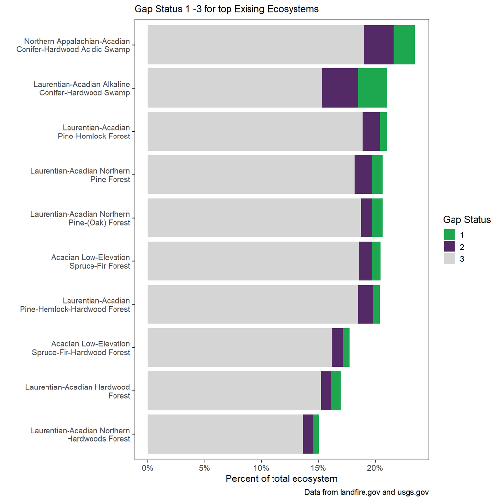

## Exploration of Successional Classes and Historical Disturbance Amounts for top Native Ecosystesm

### Reference and Current Succession Class Amounts for top Native Ecosystems

We quantified Native Ecosystems using LANDFIRE’s (Biophysical Settings)[https://landfire.gov/vegetation/bps] spatial data, “reference” succession class amounts from LANDFIRE’s (Biophysical Settings Models)[https://landfire.gov/vegetation/bps-models], and current amounts of each succession class using LANDFIRE’s (Succession Class)[https://landfire.gov/vegetation/sclass]spatial data. See more about these datasets in “Key Concepts” section below.

*We selected the top 10 Native Ecosystems for the charts below. Most Native Ecosystems have ‘variants’ representing different reference conditions (e.g., different successional stages and amounts). Therefore there may be more than 10 charts below.*

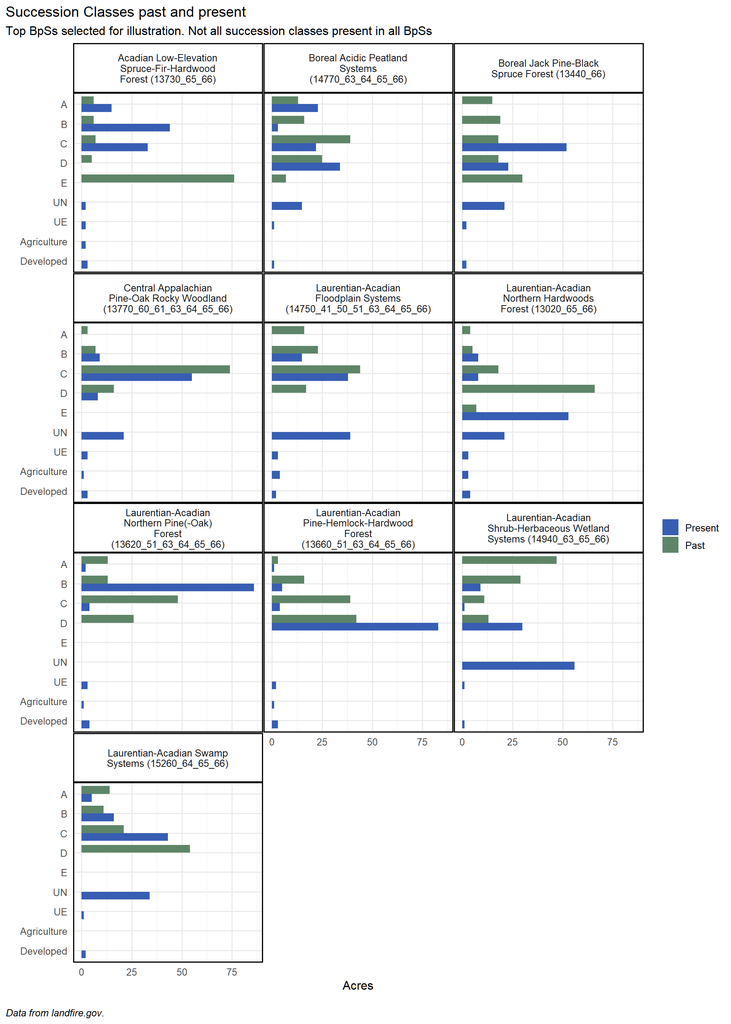

### Annual Historical Disturbance Amounts for top Native Ecosystems

In order to estimate historical amounts of succession classes, LANDFIRE used state and transition modeling with specifics captured in the (Biophysical Settings Models and Descriptions)[https://landfire.gov/vegetation/bps-models]. The transitions in this context are natural disturbances. By multiplying the modeled annual probability by the mapped amount of an BpS, we can estimate annual disturbance amounts.

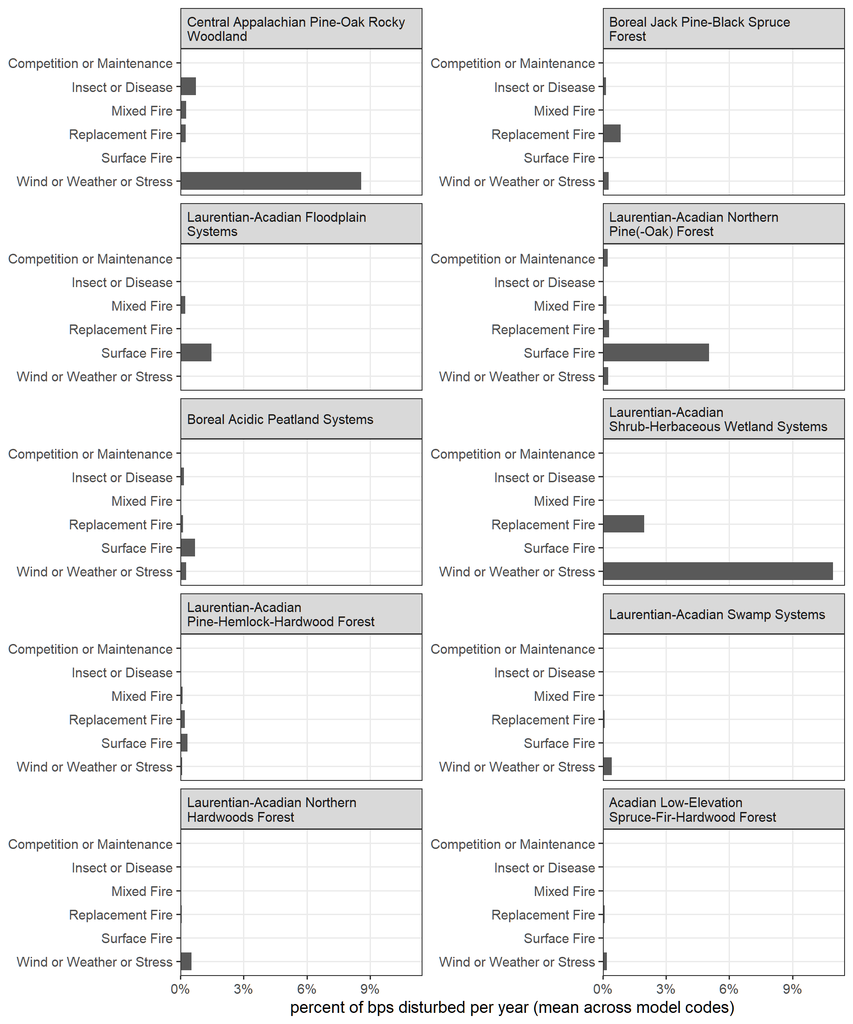

## Summary

- There were **13** Biophysical Settings (by name, there may be more if counting by variants). The **Acadian Low-Elevation Spruce-Fir-Hardwood Forest** was the most prevalent overall.
- Currently LANDFIRE maps **32** Existing Vegetation Types with the **Laurentian-Acadian Northern Hardwoods Forest** being most dominant for this Ecological Section.

## Key Concepts about the input data from LANDFIRE:

In order to better understand the the quantity of historical ecosystems, their protection status, ecological condition and natural disturbance regimes at a landscape scale, we summarized LANDFIRE and GAP data to Ecological Sections. These summaries are coarse, aimed at setting context and setting the stage for structured analysis of more local management areas.

## Native Ecosystem Descriptions and Succession Class Definitions